# How to select the best architecture?

Katarzyna Sidorczuk

3/16/2022

### Datasets

1. CD-HIT reduction using 0.9 threshold
2. Graph-part partitioning to create independent and train-test datasets. Parameters: 0.4 threshold, 0.15 ratio of validation dataset, no moving between clusters.

[output not shown]

### Choosing the best architecture

We use train-test dataset obtained after homology partitioning to perform 5-fold CV repeated 10 times. Based on the CV results we want to select the optimal architecture (highest mean kappa). We use repeated CV to reduce variance of performance measures and check architecture stability.

#### Problem 1: Differences between the models with highest mean kappa values are very small

| model | mean_kappa | mean_AU1U | mean_N_IM_sens | mean_N_OM_sens | mean_N_TM_sens | mean_N_S_sens | mean_N_TL_SEC_sens | mean_N_TL_TAT_sens | mean_P_IM_sens | mean_P_TM_sens | mean_P_S_sens | sd_N_IM_sens | sd_N_OM_sens | sd_N_TM_sens | sd_N_S_sens | sd_N_TL_SEC_sens | sd_N_TL_TAT_sens | sd_P_IM_sens | sd_P_TM_sens | sd_P_S_sens |
| --- | --- | --- | --- | --- | --- | --- | --- | --- | --- | --- | --- | --- | --- | --- | --- | --- | --- | --- | --- | --- |
| Architecture_v18_4-1_No_filtering_RF | 0.869193355379868 | 0.796145275501 | 0.316 | 0.221333333333333 | 0.715465587044534 | 0.935172413793103 | 0.684285714285714 | 0.647912087912088 | 0.958528138528139 | 0.997947402738535 | 0.950555555555556 | 0.130364803883838 | 0.0998317204827887 | 0.0544768882399333 | 0.0357395247149766 | 0.143921029242691 | 0.151110152964638 | 0.0494630251012765 | 0.00320313768494739 | 0.0209244634259525 |
| Architecture_v18_3-4_No_filtering_RF | 0.868954956732068 | 0.7947961603859 | 0.308 | 0.234222222222222 | 0.712361673414305 | 0.935184513006655 | 0.684285714285714 | 0.644835164835165 | 0.96034632034632 | 0.997948272114758 | 0.950555555555556 | 0.127429395197694 | 0.116185779727046 | 0.0611383411639662 | 0.0351012982907277 | 0.143921029242691 | 0.150773783488707 | 0.0498331159375452 | 0.00352525604052764 | 0.0191708578184652 |
| Architecture_v18_2-5_No_filtering_RF | 0.868529299821637 | 0.794144357395492 | 0.292 | 0.238666666666667 | 0.715438596491228 | 0.936600120992136 | 0.678571428571429 | 0.638901098901099 | 0.956623376623377 | 0.998134318626386 | 0.95 | 0.125885503721303 | 0.115645370806522 | 0.0606142201743693 | 0.0291230780748959 | 0.138633868820053 | 0.141890863591602 | 0.0513774815204233 | 0.00320274010239299 | 0.0195300238084131 |
| Architecture_v18-Sec_4-1_No_filtering_RF | 0.867467987850174 | 0.79266425369674 | 0.312 | 0.216888888888889 | 0.731093117408907 | 0.928203266787659 | 0.645714285714286 | 0.617582417582418 | 0.958528138528139 | 0.998320365138013 | 0.95 | 0.143620995809482 | 0.090434510493796 | 0.0690063318905006 | 0.0385443546173605 | 0.159967165331672 | 0.147680747746291 | 0.0484687704412482 | 0.00310924339355093 | 0.0194452051945594 |
| Architecture_v18_3-2_No_filtering_RF | 0.867381919228992 | 0.793924267492181 | 0.28 | 0.216888888888889 | 0.71859649122807 | 0.932401693889897 | 0.678571428571429 | 0.638901098901099 | 0.958528138528139 | 0.998320365138013 | 0.95 | 0.11819129783671 | 0.0903684300976653 | 0.0581226288262029 | 0.0382888101584245 | 0.138633868820053 | 0.141890863591602 | 0.0494630251012765 | 0.00310924339355093 | 0.0201019515306855 |
| Architecture_v13_0-1_No_filtering_RF | 0.86691376002994 | 0.786922514618012 | 0.3 | 0.229333333333333 | 0.718731443994602 | 0.930949788263763 | 0.678571428571429 | 0.607912087912088 | 0.962337662337662 | 0.998133449250163 | 0.95 | 0.137761083492134 | 0.10968148593337 | 0.0725285237377107 | 0.0354630706798211 | 0.138633868820053 | 0.159561602162717 | 0.0490189339123514 | 0.00310964097610534 | 0.0191934139648987 |
| Architecture_v18-Sec_2-5_No_filtering_RF | 0.86684077091656 | 0.790741687998283 | 0.292 | 0.238666666666667 | 0.727935222672065 | 0.92540834845735 | 0.667142857142857 | 0.611208791208791 | 0.9604329004329 | 0.998320365138013 | 0.949444444444444 | 0.129473488048875 | 0.123780222566114 | 0.0671046282175796 | 0.0367239820093413 | 0.13728026000703 | 0.159146684757245 | 0.0490189339123514 | 0.00310924339355093 | 0.0185770674964131 |
| Architecture_v18-Sec_3-4_No_filtering_RF | 0.866690958738254 | 0.79076318706459 | 0.316 | 0.225333333333333 | 0.727962213225371 | 0.926134301270417 | 0.645714285714286 | 0.608351648351648 | 0.958528138528139 | 0.998320365138013 | 0.95 | 0.130264422766756 | 0.122373014238834 | 0.0682566525273522 | 0.0373055220855679 | 0.159967165331672 | 0.153059622138553 | 0.0484687704412482 | 0.00310924339355093 | 0.0195300238084131 |
| Architecture_v16-Sec_2-3_No_filtering_RF | 0.866174475710271 | 0.787312885550315 | 0.296 | 0.224888888888889 | 0.71748987854251 | 0.930356926799758 | 0.657142857142857 | 0.623516483516484 | 0.9604329004329 | 0.997947402738535 | 0.949444444444444 | 0.124547180075086 | 0.136829671759394 | 0.0704746875053856 | 0.0375537259153532 | 0.14227826967683 | 0.137985170691311 | 0.049680270054298 | 0.00352565362308204 | 0.0175115318651744 |
| Architecture_v18-Sec_3-2_No_filtering_RF | 0.866057705270481 | 0.790671865456305 | 0.288 | 0.216888888888889 | 0.729014844804318 | 0.924706594071385 | 0.650714285714286 | 0.62043956043956 | 0.958528138528139 | 0.998320365138013 | 0.95 | 0.125319177010562 | 0.090434510493796 | 0.064646854511024 | 0.0408012333748095 | 0.160141096471458 | 0.154167295403207 | 0.0494630251012765 | 0.00310924339355093 | 0.0194452051945594 |

[output cut: 3206 more lines]

#### Problem 2: Architectures with highest kappa values tend to have higher standard deviations of performance especially for the most problematic localizations (N_OM, N_IM)

| model | rep | fold | AU1U | kappa | weighted_kappa | N_IM_sensitivity | N_OM_sensitivity | N_TM_sensitivity | N_S_sensitivity | N_TL_SEC_sensitivity | N_TL_TAT_sensitivity | P_IM_sensitivity | P_TM_sensitivity | P_S_sensitivity |
| --- | --- | --- | --- | --- | --- | --- | --- | --- | --- | --- | --- | --- | --- | --- |
| Architecture_v18_2-5_No_filtering_RF | rep1 | 5 | 0.765117978674842 | 0.893725627656312 | -11.0577803394571 | 0.4 | 0.333333333333333 | 0.789473684210526 | 0.964912280701754 | 0.714285714285714 | 0.692307692307692 | 1 | 0.995327102803738 | 0.944444444444444 |
| Architecture_v18_2-5_No_filtering_RF | rep1 | 2 | 0.79326611281541 | 0.865583604816372 | -10.166467936201 | 0.2 | 0.222222222222222 | 0.717948717948718 | 0.948275862068966 | 0.5 | 0.714285714285714 | 1 | 0.995348837209302 | 0.944444444444444 |
| Architecture_v18_2-5_No_filtering_RF | rep1 | 4 | 0.781133965184704 | 0.863893889848257 | -9.85617491015383 | 0.1 | 0.444444444444444 | 0.605263157894737 | 0.982456140350877 | 0.428571428571429 | 0.692307692307692 | 1 | 1 | 0.944444444444444 |
| Architecture_v18_2-5_No_filtering_RF | rep1 | 3 | 0.796533392118932 | 0.856607780104403 | -10.0669534716625 | 0.3 | 0.111111111111111 | 0.684210526315789 | 0.894736842105263 | 0.714285714285714 | 0.538461538461538 | 0.952380952380952 | 1 | 0.972222222222222 |
| Architecture_v18_2-5_No_filtering_RF | rep1 | 1 | 0.786955902069717 | 0.865917965966422 | -11.0333725526183 | 0.1 | 0.4 | 0.717948717948718 | 0.948275862068966 | 0.75 | 0.714285714285714 | 0.909090909090909 | 1 | 0.930555555555556 |
| Architecture_v18_2-5_No_filtering_RF | rep2 | 3 | 0.785699329652654 | 0.860442917143948 | -9.93279164384226 | 0.1 | 0.333333333333333 | 0.710526315789474 | 0.87719298245614 | 0.428571428571429 | 0.769230769230769 | 1 | 1 | 0.958333333333333 |
| Architecture_v18_2-5_No_filtering_RF | rep2 | 1 | 0.82349784376653 | 0.8731919952447 | -10.9277039918626 | 0.5 | 0.2 | 0.743589743589744 | 0.948275862068966 | 0.875 | 0.357142857142857 | 1 | 1 | 0.944444444444444 |
| Architecture_v18_2-5_No_filtering_RF | rep2 | 4 | 0.80445865638499 | 0.870017905696664 | -10.8272391787126 | 0.5 | 0.444444444444444 | 0.710526315789474 | 0.964912280701754 | 0.571428571428571 | 0.538461538461538 | 0.904761904761905 | 1 | 0.916666666666667 |
| Architecture_v18_2-5_No_filtering_RF | rep2 | 2 | 0.782857426560245 | 0.861823002600996 | -11.1352116619326 | 0.3 | 0.222222222222222 | 0.641025641025641 | 0.896551724137931 | 0.875 | 0.642857142857143 | 1 | 1 | 0.958333333333333 |
| Architecture_v18_2-5_No_filtering_RF | rep2 | 5 | 0.788649091676963 | 0.857112349870029 | -9.99815093776264 | 0.2 | 0.111111111111111 | 0.736842105263158 | 0.912280701754386 | 0.714285714285714 | 0.692307692307692 | 0.904761904761905 | 0.990654205607477 | 0.958333333333333 |

[output cut: 115 more lines]

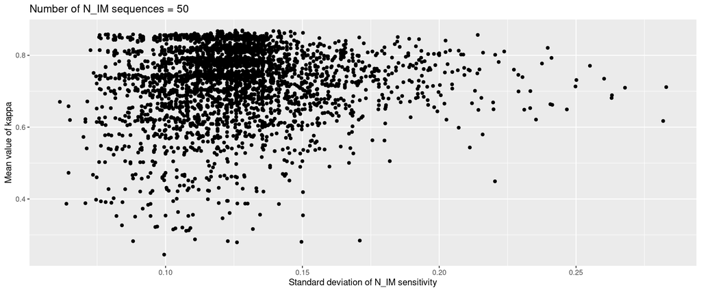

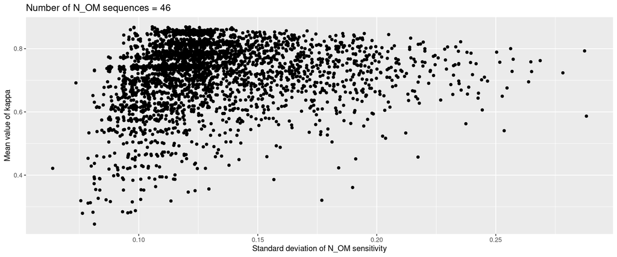

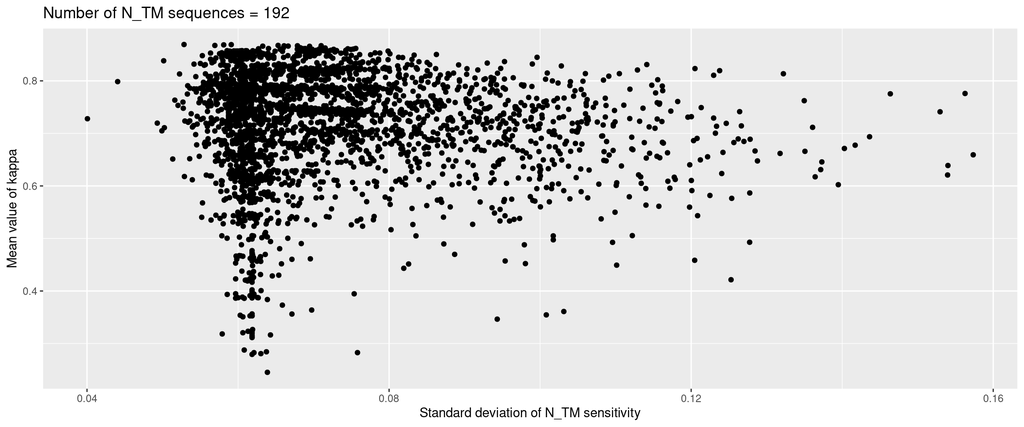

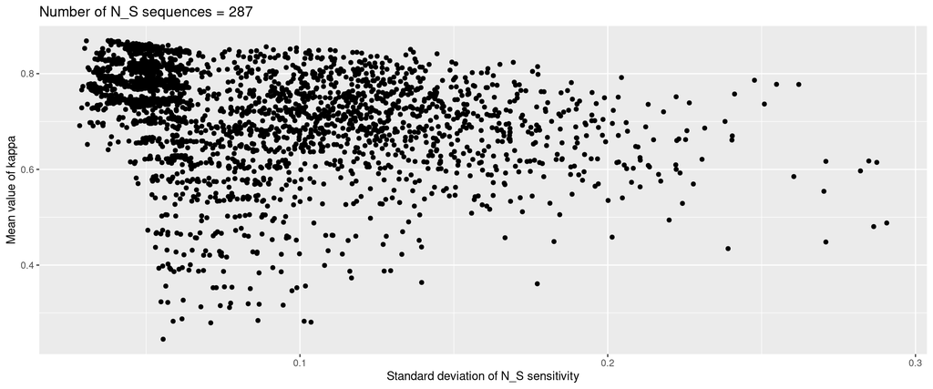

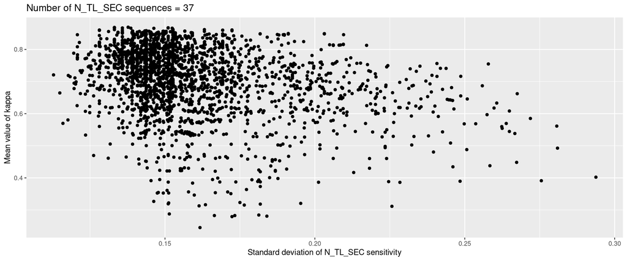

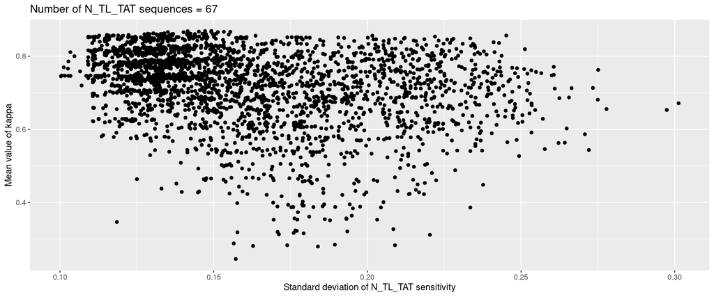

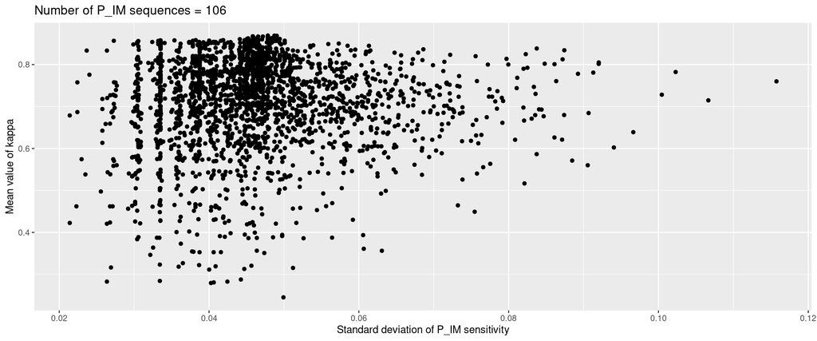

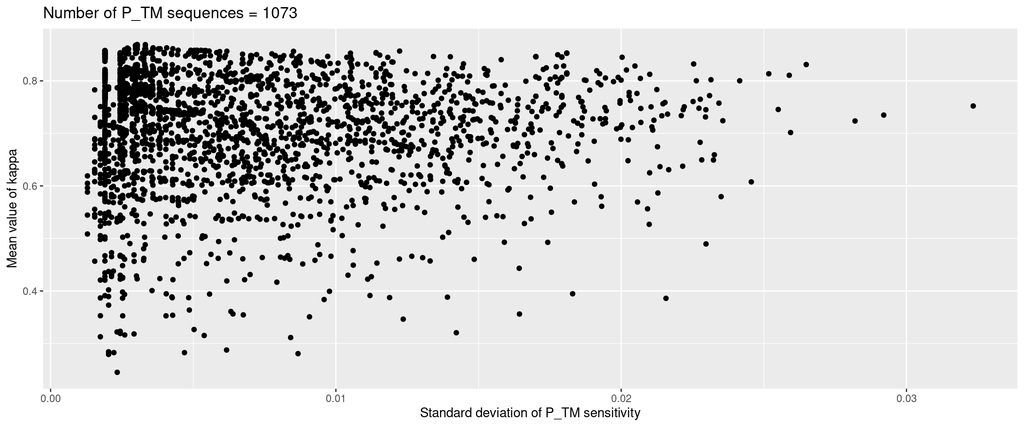

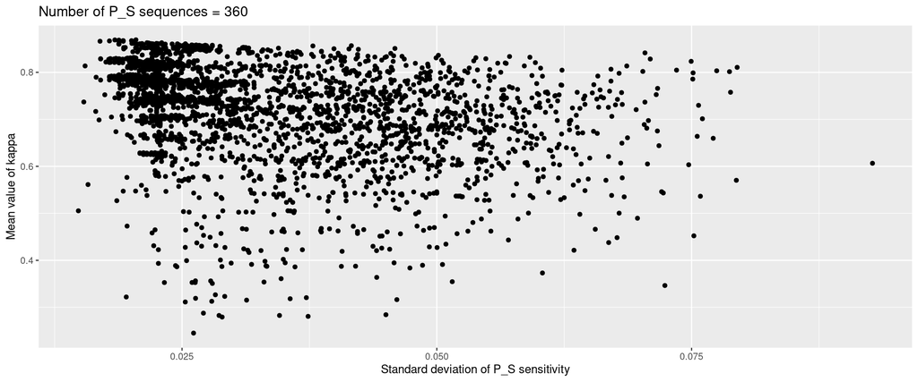

### Questions

**How to select the best architecture?** - select the one with the highest kappa regardless of standard deviations? Include standard deviations in the decision (how?)? use some other method?

**Independent dataset** - is that enough? Test it on proteins from other organisms not possesing ‘typical’ chloroplasts, such as *Paulinella* or *Plasmodium* (problem with data availability - will have to check the literature).

**Jackknife** - everyone else is doing that but it has its problems (tends to overestimate model performance, doesn’t work well with GLMs)